# **predicting the success of bank telemarketing using logistic regression**

dataset avalable at: https://archive.ics.uci.edu/ml/datasets/bank+marketing#

## importing required libraries

```python
import pandas as pd
import matplotlib.pyplot as plt
import seaborn as sns
import numpy as np
```

## Data exploration

```python
# loading the data
data=pd.read_csv('dataset/bank-additional.csv',sep=";")
data.head()
```

|  | age | job | marital | education | default | housing | loan | contact | month | day_of_week | ... | campaign | pdays | previous | poutcome | emp.var.rate | cons.price.idx | cons.conf.idx | euribor3m | nr.employed | y |
| --- | --- | --- | --- | --- | --- | --- | --- | --- | --- | --- | --- | --- | --- | --- | --- | --- | --- | --- | --- | --- | --- |
| 0 | 30 | blue-collar | married | basic.9y | no | yes | no | cellular | may | fri | ... | 2 | 999 | 0 | nonexistent | -1.8 | 92.893 | -46.2 | 1.313 | 5099.1 | no |
| 1 | 39 | services | single | high.school | no | no | no | telephone | may | fri | ... | 4 | 999 | 0 | nonexistent | 1.1 | 93.994 | -36.4 | 4.855 | 5191.0 | no |
| 2 | 25 | services | married | high.school | no | yes | no | telephone | jun | wed | ... | 1 | 999 | 0 | nonexistent | 1.4 | 94.465 | -41.8 | 4.962 | 5228.1 | no |
| 3 | 38 | services | married | basic.9y | no | unknown | unknown | telephone | jun | fri | ... | 3 | 999 | 0 | nonexistent | 1.4 | 94.465 | -41.8 | 4.959 | 5228.1 | no |
| 4 | 47 | admin. | married | university.degree | no | yes | no | cellular | nov | mon | ... | 1 | 999 | 0 | nonexistent | -0.1 | 93.200 | -42.0 | 4.191 | 5195.8 | no |

5 rows × 21 columns

```python
data.info()
```

```
<class 'pandas.core.frame.DataFrame'>
RangeIndex: 4119 entries, 0 to 4118
Data columns (total 21 columns):
 #   Column          Non-Null Count  Dtype
---  ------          --------------  -----
 0   age             4119 non-null   int64
 1   job             4119 non-null   object
 2   marital         4119 non-null   object
 3   education       4119 non-null   object
 4   default         4119 non-null   object
 5   housing         4119 non-null   object
 6   loan            4119 non-null   object
 7   contact         4119 non-null   object
 8   month           4119 non-null   object
 9   day_of_week     4119 non-null   object
 10  duration        4119 non-null   int64
 11  campaign        4119 non-null   int64
 12  pdays           4119 non-null   int64
 13  previous        4119 non-null   int64
 14  poutcome        4119 non-null   object
 15  emp.var.rate    4119 non-null   float64
 16  cons.price.idx  4119 non-null   float64
 17  cons.conf.idx   4119 non-null   float64
 18  euribor3m       4119 non-null   float64
 19  nr.employed     4119 non-null   float64
 20  y               4119 non-null   object
dtypes: float64(5), int64(5), object(11)
memory usage: 675.9+ KB
```

## bank client data:

1. - age (numeric)
2. - job : type of job (categorical: "admin.","blue-collar","entrepreneur","housemaid","management","retired","self-employed","services","student","technician","unemployed","unknown")
3. - marital : marital status (categorical: "divorced","married","single","unknown"; note: "divorced" means divorced or widowed)
4. - education (categorical: "basic.4y","basic.6y","basic.9y","high.school","illiterate","professional.course","university.degree","unknown")
5. - default: has credit in default? (categorical: "no","yes","unknown")
6. - housing: has housing loan? (categorical: "no","yes","unknown")
7. - loan: has personal loan? (categorical: "no","yes","unknown") ## related with the last contact of the current campaign:
8. - contact: contact communication type (categorical: "cellular","telephone")
9. - month: last contact month of year
10. - day_of_week: last contact day of the week
11. - duration: last contact duration, in seconds (numeric). ## other attributes:
12. - campaign: number of contacts performed during this campaign and for this client (numeric, includes last contact)
13. - pdays: number of days that passed by after the client was last contacted
14. - previous: number of contacts performed before this campaign and for this client (numeric)
15. - poutcome: outcome of the previous marketing campaign (categorical: "failure","nonexistent","success") ## social and economic context attributes
16. - emp.var.rate: employment variation rate
17. - cons.price.idx: consumer price index
18. - cons.conf.idx: consumer confidence index
19. - euribor3m: euribor 3 month rate
20. - nr.employed: number of employees

## Output variable (desired target):

1. - y - has the client subscribed a term deposit? (binary: "yes","no")

```python
def plot_value_count_table(data, feild):
    print(feild)

    fig, ax = plt.subplots()
    fig.tight_layout()
    fig.patch.set_visible(False)
    ax.axis('off')
    ax.axis('tight')
    df = pd.DataFrame({
        'index': data[feild].value_counts().index,
        'values': data[feild].value_counts().values,
    })
    table = ax.table(cellText=df.values, colLabels=['index', 'value'], loc='center')
    plt.show()
```

#### counting the number of unique values in all of the categorical columns, (printing it as table)

```
job
```

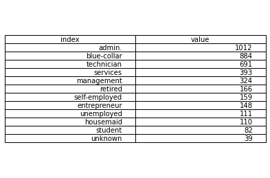

```
marital
```

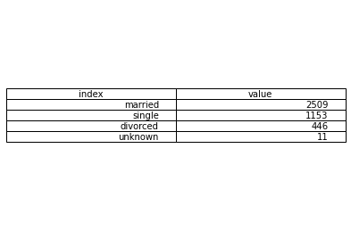

```
education
```

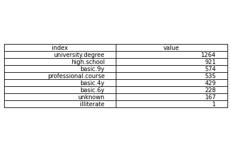

```
default
```

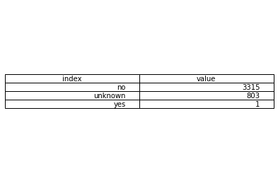

```
housing
```

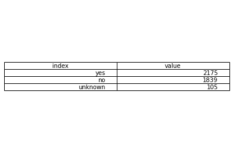

```
loan
```

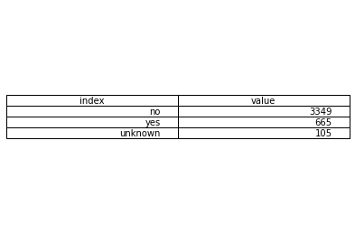

```
contact
```

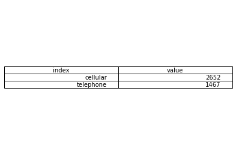

```
month
```

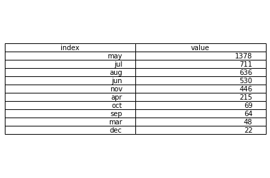

```
day_of_week
```

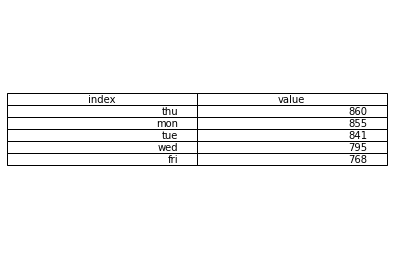

```
poutcome
```

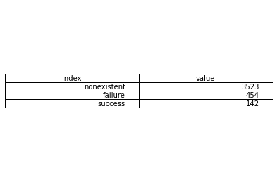

```
y
```

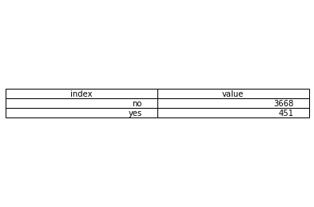

```python
    for i in data.select_dtypes('object').columns.to_list():
        plot_value_count_table(data, i)
```

# Data analysis and Cleaning

```python
# checking for missing values
data.isna().sum().sum()
```

```
0
```

```python
# replacing all the 'unknown' values with NaN values and checking again
data.replace('unknown', np.NaN, inplace=True)
data.isna().sum().sum()
```

```
1230
```

```python
# dropping all the missing values
data = data.dropna()
data.isna().sum().sum()
```

```
0
```

```python
# checking for any duplicated values
data.duplicated().sum()
```

```
0
```

```python
# exploring 'education' variable
data['education'].value_counts()
```

```
university.degree      1107
high.school             728
professional.course     454
basic.9y                407
basic.4y                243
basic.6y                150
illiterate                1
Name: education, dtype: int64
```

```python
data = data.drop(data[data['education'] == 'illiterate'].index)
for i in ['basic.9y','basic.6y','basic.4y']:
    data.loc[data['education'] == i, 'education'] = 'basic.school'

data['education'].value_counts()
```

```
university.degree      1107
basic.school            800
high.school             728
professional.course     454
Name: education, dtype: int64
```

```python
# exploring 'pdays' variable
# replacing the value 999 with 0
data.loc[data['pdays'] == 999, 'pdays'] = 0
data['pdays'].value_counts()
```

```
0     2949
3       46
6       40
4       13
10       8
7        6
12       5
5        4
2        4
1        3
15       2
9        2
13       2
18       1
11       1
19       1
16       1
21       1
Name: pdays, dtype: int64
```

```python
# dropping 'duration' column
data = data.drop(["duration"], axis = 1)
```

### visualizations

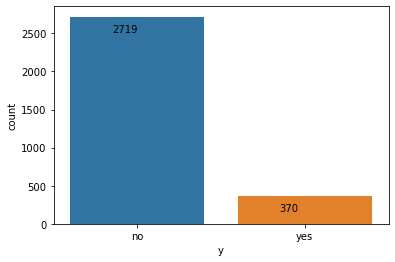

```python
# plotting our target variable, which is the column 'y'
ax = sns.countplot(x = data["y"])
for p in ax.patches:
    ax.annotate(f"{p.get_height()}", (p.get_x()+0.25, p.get_height()-200))
plt.show()
```

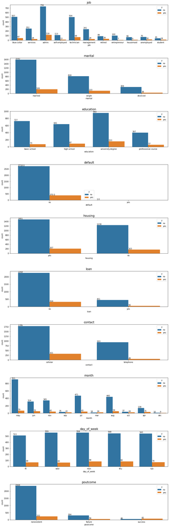

```python
# visualizing all the Categorical variables relative to your target variable known as 'y'
cat = data.select_dtypes('object').columns.to_list()
cat = cat[:-1]
fig, axis = plt.subplots(len(cat), figsize=(15, 50))
axs_cnt = 0
for i in cat:
    axis[axs_cnt].set_title(i, fontdict={'fontsize':15})
    sns.countplot(x = data[i], hue=data["y"], ax=axis[axs_cnt])
    for p in axis[axs_cnt].patches:
        axis[axs_cnt].annotate(f"{p.get_height()}", (p.get_x()+0, p.get_height()+12))

    axs_cnt = axs_cnt+1
plt.subplots_adjust(hspace=0.5)
plt.show()
```

```python
# dropping 'default' column
data  = data.drop(["default"], axis = 1)
```

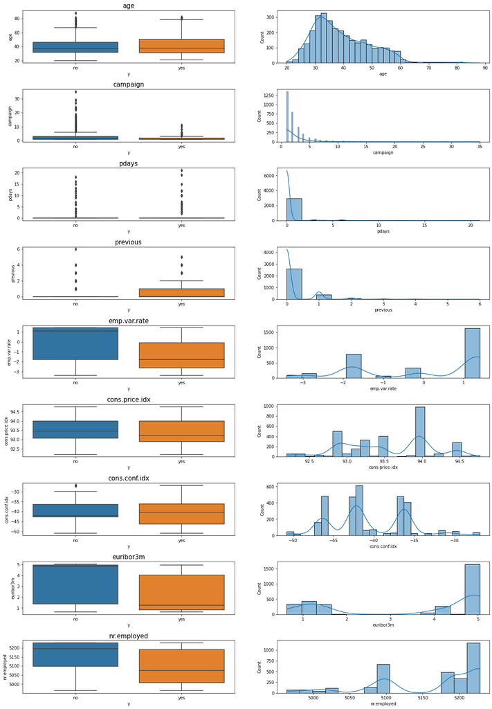

```python
# plotting all the numerical variables relative to your target variable known as 'y'

cat = data.select_dtypes(['float64', 'int64']).columns.to_list()
fig, axis = plt.subplots(len(cat),2, figsize=(20,30))
axs_cnt = 0
for i in cat:
    axs = axis[axs_cnt]
    sns.boxplot(data=data, x="y", y=i, ax=axs[0])
    axs[0].set_title(i, fontdict={'fontsize':15})
    sns.histplot(data[i], ax=axs[1],kde=True)

    axs_cnt = axs_cnt+1
plt.subplots_adjust(hspace=0.5)
plt.show()
```

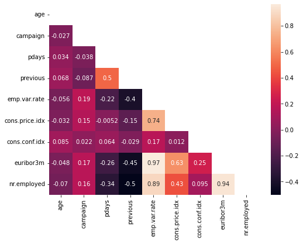

```python
# checking correlation between variables
plt.figure(figsize=(8, 6))
mask = np.triu(np.ones_like(data.corr(), dtype=bool))
sns.heatmap(data.corr(), mask=mask, annot=True);
```

**correlated variables:** emp.var.rate, euribor3m, nr.employed

```python
# calculating VIF (Variance Inflation Factor) on correlated variables

from statsmodels.stats.outliers_influence import variance_inflation_factor
vif_x = data[['emp.var.rate','euribor3m', 'nr.employed']]
# new dataframe
vif_data = pd.DataFrame()
vif_data["Variable"] = vif_x.columns

# calculating VIF
vif_data["VIF"] = [variance_inflation_factor(vif_x.values, i)for i in range(len(vif_x.columns))]

vif_data
```

|  | Variable | VIF |
| --- | --- | --- |
| 0 | emp.var.rate | 15.941354 |
| 1 | euribor3m | 82.138343 |
| 2 | nr.employed | 68.182701 |

```python
# removing the correlated variables which has the highest VIF
data = data.drop(['euribor3m', 'nr.employed'], axis = 1)
```

```python
data.head()
```

|  | age | job | marital | education | housing | loan | contact | month | day_of_week | campaign | pdays | previous | poutcome | emp.var.rate | cons.price.idx | cons.conf.idx | y |
| --- | --- | --- | --- | --- | --- | --- | --- | --- | --- | --- | --- | --- | --- | --- | --- | --- | --- |
| 0 | 30 | blue-collar | married | basic.school | yes | no | cellular | may | fri | 2 | 0 | 0 | nonexistent | -1.8 | 92.893 | -46.2 | no |
| 1 | 39 | services | single | high.school | no | no | telephone | may | fri | 4 | 0 | 0 | nonexistent | 1.1 | 93.994 | -36.4 | no |
| 2 | 25 | services | married | high.school | yes | no | telephone | jun | wed | 1 | 0 | 0 | nonexistent | 1.4 | 94.465 | -41.8 | no |
| 4 | 47 | admin. | married | university.degree | yes | no | cellular | nov | mon | 1 | 0 | 0 | nonexistent | -0.1 | 93.200 | -42.0 | no |
| 5 | 32 | services | single | university.degree | no | no | cellular | sep | thu | 3 | 0 | 2 | failure | -1.1 | 94.199 | -37.5 | no |

# Data processing

**process our dataset so that it will fit into the model**

1. label encode all the Categorical variables
2. split into X and Y
3. split into train and test
4. Standardizes the data

```python
# label encoding the variables
from sklearn.preprocessing import LabelEncoder
d_types = dict(data.dtypes)
for name , type_ in d_types.items():
    if str(type_) == 'object':
        Le = LabelEncoder()
        data[name] = Le.fit_transform(data[name])
```

```python
data.head()
```

|  | age | job | marital | education | housing | loan | contact | month | day_of_week | campaign | pdays | previous | poutcome | emp.var.rate | cons.price.idx | cons.conf.idx | y |
| --- | --- | --- | --- | --- | --- | --- | --- | --- | --- | --- | --- | --- | --- | --- | --- | --- | --- |
| 0 | 30 | 1 | 1 | 0 | 1 | 0 | 0 | 6 | 0 | 2 | 0 | 0 | 1 | -1.8 | 92.893 | -46.2 | 0 |
| 1 | 39 | 7 | 2 | 1 | 0 | 0 | 1 | 6 | 0 | 4 | 0 | 0 | 1 | 1.1 | 93.994 | -36.4 | 0 |
| 2 | 25 | 7 | 1 | 1 | 1 | 0 | 1 | 4 | 4 | 1 | 0 | 0 | 1 | 1.4 | 94.465 | -41.8 | 0 |
| 4 | 47 | 0 | 1 | 3 | 1 | 0 | 0 | 7 | 1 | 1 | 0 | 0 | 1 | -0.1 | 93.200 | -42.0 | 0 |
| 5 | 32 | 7 | 2 | 3 | 0 | 0 | 0 | 9 | 2 | 3 | 0 | 2 | 0 | -1.1 | 94.199 | -37.5 | 0 |

```python
# splitting data into x and y
x = data.iloc[:, 1:-1].values
y = data.iloc[:, -1].values
```

```python
# splitting the data into subset of test and train data
from sklearn.model_selection import train_test_split
Xtrain , Xtest , Ytrain , Ytest = train_test_split(x, y, test_size = 0.2 , random_state = 4)
```

```python
# checking the shape of the subset data
print('shape of train and test data:')
print(f"Xtrain: {Xtrain.shape}")
print(f"Ytrain: {Ytrain.shape}")
print(f"Xtest: {Xtest.shape}")
print(f"Xtest: {Ytest.shape}")
```

```
shape of train and test data:
Xtrain: (2471, 15)
Ytrain: (2471,)
Xtest: (618, 15)
Xtest: (618,)
```

```python
# standardizes the data
from sklearn.preprocessing import StandardScaler
Scaler = StandardScaler()
Xtrain = Scaler.fit_transform(Xtrain)
Xtest = Scaler.transform(Xtest)
```

# Model

```python
# importing logistic regression from sklearn
from sklearn.linear_model import LogisticRegression
```

```python
model = LogisticRegression()
model.fit(Xtrain , Ytrain)
```

```
LogisticRegression()
```

### Evaluating the Model

```python
from sklearn.metrics import classification_report, accuracy_score
```

```python
# running predictions
predictions = model.predict(Xtest)
report=classification_report(Ytest, predictions,output_dict=True)

report = pd.DataFrame(report).transpose()
report
```

|  | precision | recall | f1-score | support |
| --- | --- | --- | --- | --- |
| 0 | 0.920204 | 0.981884 | 0.950044 | 552.000000 |
| 1 | 0.655172 | 0.287879 | 0.400000 | 66.000000 |
| accuracy | 0.907767 | 0.907767 | 0.907767 | 0.907767 |
| macro avg | 0.787688 | 0.634881 | 0.675022 | 618.000000 |
| weighted avg | 0.891899 | 0.907767 | 0.891301 | 618.000000 |

```python
print(f"accuracy score: {accuracy_score(predictions, Ytest)*100}")
```

```
accuracy score: 90.77669902912622
```